[figure not shown]

# LINEAIRE REGRESSIE - TOEPASSING TRENDLIJN - POSTPAKKEN

In deze notebook krijg je een gelijksoortige opdracht voorgeschoteld als in de notebook 'Lineaire regressie - Toepassing trendlijn - Post'.

### Opdracht

In de figuur zie je dat het aantal postpakken dat een Belg per jaar verstuurt, gestegen is in de periode 2010-2015.

Je bekijkt het aantal verstuurde postpakken per Belg per jaar in functie van het jaartal.  
Haal de data die je nodig hebt uit de figuur.

Vervolgens bepaal je:

- de mate van samenhang tussen het jaartal en het aantal postpakken a.d.h.v. de correlatiecoëfficiënt;
- de vergelijking van de **trendlijn**.

Tot slot stel je de gegeven data en de trendlijn duidelijk voor op een grafiek.

- Tussen welke grootheden is er het meeste samenhang: tussen het aantal brieven en het jaartal of tussen het aantal postpakken en het jaartal?

[figure not shown]

Figuur 1: Postbode komt niet meer elke dag aan huis. [1]

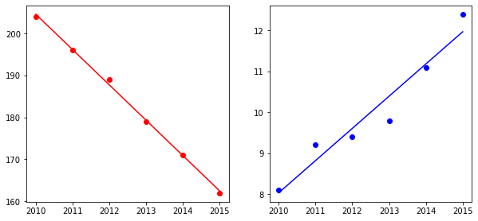

```
    Brieven -0.9990819895936358             Pakketjes 0.9677362246712373

    Er is 3.14% meer samenhang bij de brieven
```

```python
import numpy as np
import matplotlib.pyplot as plt
import pandas as pd

from scipy.optimize import curve_fit


def _rechte(x, a, b):
    return a * x + b


def _linreg(x, y):
    popt, pcov = curve_fit(_rechte, x, y)

    a, b = popt
    return a, b


x = np.array([2010, 2011, 2012, 2013, 2014, 2015])
yb = np.array([204, 196, 189, 179, 171, 162])
yp = np.array([8.1, 9.2, 9.4, 9.8, 11.1, 12.4])

ab, bb = _linreg(x, yb)
ap, bp = _linreg(x, yp)

plt.figure(figsize=(10, 10))

plt.subplot(2, 2, 1)
plt.scatter(x, yb, color="red")
plt.plot(x, _rechte(x, ab, bb), color="red")

plt.subplot(2, 2, 2)
plt.scatter(x, yp, color="blue")
plt.plot(x, _rechte(x, ap, bp), color="blue")

plt.show()

coefb = np.corrcoef(x, yb)[0,1]
coefp = np.corrcoef(x, yp)[0,1]

verschil = abs((abs(coefp) - abs(coefb)) / abs(coefb) * 100)

print('    Brieven', coefb, '            Pakketjes', coefp)
print(f'\n    Er is {verschil:.2f}% meer samenhang bij de brieven')
```

## Referentielijst

[1] tlb, mtm. (21 februari 2017). Postbode komt niet meer elke dag aan huis. *Het Nieuwsblad*. https://www.nieuwsblad.be/cnt/dmf20170220_02742099

Notebook Python in wiskunde, zie Computationeel denken - Programmeren in Python van [AI Op School](http://www.aiopschool.be), van F. wyffels & N. Gesquière, in licentie gegeven volgens een [Creative Commons Naamsvermelding-NietCommercieel-GelijkDelen 4.0 Internationaal-licentie](http://creativecommons.org/licenses/by-nc-sa/4.0/).